# would_you_survive_titanic slides

## The Data at First Glance: Who Survived the Titanic and Why?

First, import the required Python dependencies.

```python
import matplotlib.pyplot as plt
%matplotlib inline
import numpy as np
import pandas as pd
from sklearn import cross_validation, tree, preprocessing, metrics
from IPython.display import Image, display
from sklearn.cross_validation import train_test_split
from sklearn.cross_validation import KFold
from sklearn.cross_validation import cross_val_score
from sklearn import tree
```

Once we have read the csv file into a Pandas dataframe, we can peek at the first five rows of data using the head() command.

```python
titanic_train = pd.read_csv('data/train.csv')
titanic_train.head()
```

|  | PassengerId | Survived | Pclass | Name | Sex | Age | SibSp | Parch | Ticket | Fare | Cabin | Embarked |
| --- | --- | --- | --- | --- | --- | --- | --- | --- | --- | --- | --- | --- |
| 0 | 1 | 0 | 3 | Braund, Mr. Owen Harris | male | 22 | 1 | 0 | A/5 21171 | 7.2500 | NaN | S |
| 1 | 2 | 1 | 1 | Cumings, Mrs. John Bradley (Florence Briggs Th... | female | 38 | 1 | 0 | PC 17599 | 71.2833 | C85 | C |
| 2 | 3 | 1 | 3 | Heikkinen, Miss. Laina | female | 26 | 0 | 0 | STON/O2. 3101282 | 7.9250 | NaN | S |
| 3 | 4 | 1 | 1 | Futrelle, Mrs. Jacques Heath (Lily May Peel) | female | 35 | 1 | 0 | 113803 | 53.1000 | C123 | S |
| 4 | 5 | 0 | 3 | Allen, Mr. William Henry | male | 35 | 0 | 0 | 373450 | 8.0500 | NaN | S |

Now that we have the data in a dataframe, we can begin an advanced analysis of the data using powerful single-line Pandas functions. First, let’s examine the overall chance of survival for a Titanic passenger.

```python
titanic_train['Survived'].mean()
```

```
0.3838383838383838
```

The calculation shows that only 38% of the passengers survived. Not the best odds. The reason for this massive loss of life is that the Titanic was only carrying 20 lifeboats, which was not nearly enough for the 1,317 passengers and 885 crew members aboard. It seems unlikely that all of the passengers would have had equal chances at survival, so we will continue breaking down the data to examine the social dynamics that determined who got a place on a lifeboat and who did not.

Social classes were heavily stratified in the early twentieth century. This was especially true on the Titanic, where the luxurious first-class areas were completely off limits to the middle-class passengers in second class, and especially to those who carried a third class “economy price” ticket. To get a view into the composition of each class, we can group data by class, and view the averages for each column:

```python
titanic_train.groupby('Pclass')[['Survived', 'Age']].mean()
```

| Pclass | Survived | Age |
| --- | --- | --- |
| 1 | 0.629630 | 38.233441 |
| 2 | 0.472826 | 29.877630 |
| 3 | 0.242363 | 25.140620 |

We can start drawing some interesting insights from this data. For instance, passengers in first class had a 63% chance of survival, compared to a 24% chance for those in 3rd class. Additionally, the lower classes generally consisted of younger people.

We can extend our statistical breakdown using the grouping function for both class and sex:

```python
class_sex_grouping = titanic_train.groupby(['Pclass','Sex']).mean()
class_sex_grouping
```

| Pclass | Sex | PassengerId | Survived | Age | SibSp | Parch | Fare |
| --- | --- | --- | --- | --- | --- | --- | --- |
| 1 | female | 469.212766 | 0.968085 | 34.611765 | 0.553191 | 0.457447 | 106.125798 |
|  | male | 455.729508 | 0.368852 | 41.281386 | 0.311475 | 0.278689 | 67.226127 |
| 2 | female | 443.105263 | 0.921053 | 28.722973 | 0.486842 | 0.605263 | 21.970121 |
|  | male | 447.962963 | 0.157407 | 30.740707 | 0.342593 | 0.222222 | 19.741782 |
| 3 | female | 399.729167 | 0.500000 | 21.750000 | 0.895833 | 0.798611 | 16.118810 |
|  | male | 455.515850 | 0.135447 | 26.507589 | 0.498559 | 0.224784 | 12.661633 |

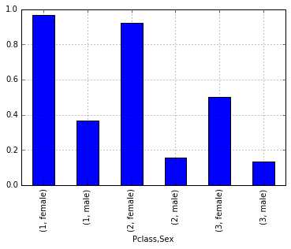

```python
class_sex_grouping['Survived'].plot(x = ['Pclass, Sex'], y = 'Survived', kind = 'bar')
```

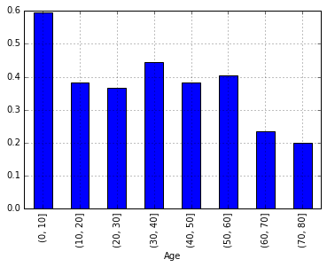

```python
group_by_age = pd.cut(titanic_train["Age"], np.arange(0, 90, 10))
age_grouping = titanic_train.groupby(group_by_age).mean()
age_grouping['Survived'].plot(x = 'Age', y = 'Survived', kind = 'bar')
```

Here we can see that children were indeed the most likely age group to survive, although this percentage was still tragically below 60%.

### Preparing The Data

Before we can feed our data set into a machine learning algorithm, we have to impute missing values.

If we perform a count of each column, we will see that much of the data on certain fields is missing. Most machine learning algorithms will have a difficult time handling missing values, so we will need to make sure that each row has a value for each column.

```python
titanic_train.count()
```

```
PassengerId    891
Survived       891
Pclass         891
Name           891
Sex            891
Age            714
SibSp          891
Parch          891
Ticket         891
Fare           891
Cabin          204
Embarked       889
dtype: int64
```

A significant number of rows are also missing an age value. We have seen above that age could have a significant effect on survival chances, so we will impute the missing age values using median age.

```python
new_age_var = np.where(titanic_train["Age"].isnull(), # Logical check
                       titanic_train["Age"].median(),  # Value if check is true
                       titanic_train["Age"])     # Value if check is false
titanic_train["Age"] = new_age_var
titanic_train.count()
```

```
PassengerId    891
Survived       891
Pclass         891
Name           891
Sex            891
Age            891
SibSp          891
Parch          891
Ticket         891
Fare           891
Cabin          204
Embarked       889
dtype: int64
```

## Decision Tree Model

Next, we need to initialize scikit-learn's the decision tree model and then train the model using the sex variable:

```python
# Initialize label encoder
label_encoder = preprocessing.LabelEncoder()

# Convert Sex variable to numeric
encoded_sex = label_encoder.fit_transform(titanic_train["Sex"])

# Initialize model
tree_model = tree.DecisionTreeClassifier()

# Train the model
tree_model.fit(X = pd.DataFrame(encoded_sex),
               y = titanic_train["Survived"])
```

```
DecisionTreeClassifier(class_weight=None, criterion='gini', max_depth=None,
            max_features=None, max_leaf_nodes=None, min_samples_leaf=1,
            min_samples_split=2, min_weight_fraction_leaf=0.0,
            presort=False, random_state=None, splitter='best')
```

Now let's view a visualization of the tree the model created:

```python
# Save tree as pdf file
tree.export_graphviz(tree_model, out_file='tree1.dot')
```

```python
with open("images/tree1.dot", 'w') as f:
     f = tree.export_graphviz(tree_model,
                              feature_names=["Sex"],
                              out_file=f)

#Make sure that graphviz is installed on your machine (use brew install graphviz)
#On the terminal, go to the folder that has the .dot file and run the following command:
# dot -Tpng tree1.dot -o tree1.png
```

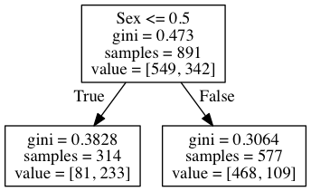

```python
display(Image("images/tree1.png"))           # Display image*
```

The tree's graph show us that it consists of only one decision node that splits the data on the variable sex. All 314 females end up in one leaf node and all 577 males end up in a different leaf node.

Let's make predictions with this tree and view a table of the results:

```python
# Get survival probability
preds = tree_model.predict_proba(X = pd.DataFrame(encoded_sex))

pd.crosstab(preds[:,0], titanic_train["Sex"])
```

| Sex row_0 | female | male |
| --- | --- | --- |
| 0.257962 | 314 | 0 |
| 0.811092 | 0 | 577 |

The table shows that the decision tree managed to create the simple gender-based model where all females survive and all males perish.

Let's create a new decision tree that adds the passenger class variable and see how it changes the resulting predictions:

```python
# Make data frame of predictors
predictors = pd.DataFrame([encoded_sex, titanic_train["Pclass"]]).T

# # Train the model
tree_model.fit(X = predictors,
               y = titanic_train["Survived"])
```

```
DecisionTreeClassifier(class_weight=None, criterion='gini', max_depth=None,
            max_features=None, max_leaf_nodes=None, min_samples_leaf=1,
            min_samples_split=2, min_weight_fraction_leaf=0.0,
            presort=False, random_state=None, splitter='best')
```

Now let's look at the graph of the new decision tree model:

```python
with open("images/tree2.dot", 'w') as f:
     f = tree.export_graphviz(tree_model,
                              feature_names=["Sex", "Class"],
                              out_file=f)
```

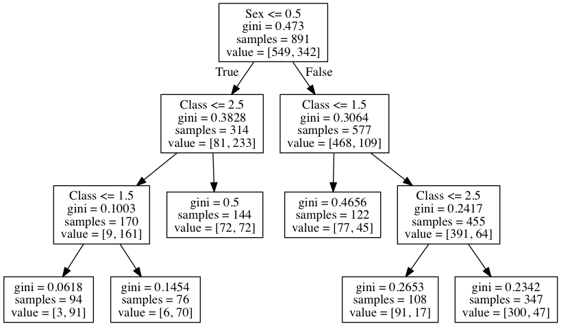

```python
display(Image("images/tree2.png"))
```

Let's make predictions and view a table of the results:

```python
# Get survival probability
preds = tree_model.predict_proba(X = predictors)

# Create a table of predictions by sex and class
pd.crosstab(preds[:,0], columns = [titanic_train["Pclass"],
                                   titanic_train["Sex"]])
```

| Pclass Sex row_0 | 1 female | 1 male | 2 female | 2 male | 3 female | 3 male |
| --- | --- | --- | --- | --- | --- | --- |
| 0.031915 | 94 | 0 | 0 | 0 | 0 | 0 |
| 0.078947 | 0 | 0 | 76 | 0 | 0 | 0 |
| 0.500000 | 0 | 0 | 0 | 0 | 144 | 0 |
| 0.631148 | 0 | 122 | 0 | 0 | 0 | 0 |
| 0.842593 | 0 | 0 | 0 | 108 | 0 | 0 |
| 0.864553 | 0 | 0 | 0 | 0 | 0 | 347 |

Notice that the more complex model still predicts a higher survival rate for women than men, but women in third class only have a 50% predicted death probability while women in first class are predicted to die less than 5% of the time.

The more variables you add to a decision tree, the more yes/no decisions it can make, resulting in a deeper, more complex tree. Adding too much complexity to a decision tree, however, makes it prone to overfitting the training data, which can lead to poor generalization to unseen data. Let's investigate by creating a larger tree with a few more variables:

```python
predictors = pd.DataFrame([encoded_sex,
                           titanic_train["Pclass"],
                           titanic_train["Age"],
                           titanic_train["Fare"]]).T

# Initialize model with maximum tree depth set to 8
tree_model = tree.DecisionTreeClassifier(max_depth = 8)

tree_model.fit(X = predictors,
               y = titanic_train["Survived"])
```

```
DecisionTreeClassifier(class_weight=None, criterion='gini', max_depth=8,
            max_features=None, max_leaf_nodes=None, min_samples_leaf=1,
            min_samples_split=2, min_weight_fraction_leaf=0.0,
            presort=False, random_state=None, splitter='best')
```

```python
with open("images/tree3.dot", 'w') as f:
     f = tree.export_graphviz(tree_model,
                              feature_names=["Sex", "Class","Age","Fare"],
                              out_file=f)
```

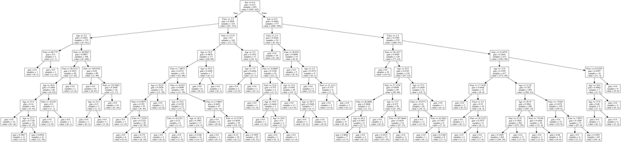

```python
display(Image("images/tree3.png"))
```

```python
tree_model.score(X = predictors,
                 y = titanic_train["Survived"])
```

```
0.88888888888888884
```

The model is almost 89% accurate on the training data, but how does it do on unseen data? Let's load the test data, make some predictions submit them to Kaggle to find out:

```python
# Read and prepare test data
titanic_test = pd.read_csv("data/test.csv")    # Read the data

# Impute median Age for NA Age values
new_age_var = np.where(titanic_test["Age"].isnull(), # Logical check
                       titanic_train["Age"].median(), # Value if check is true
                       titanic_test["Age"])      # Value if check is false

titanic_test["Age"] = new_age_var
```

```python
# Convert test variables to match model features
encoded_sex_test = label_encoder.fit_transform(titanic_test["Sex"])

test_features = pd.DataFrame([encoded_sex_test,
                              titanic_test["Pclass"],
                              titanic_test["Age"],
                              titanic_test["Fare"]]).T

titanic_test = titanic_test[~test_features.isnull().any(axis = 1)]
test_features.dropna(inplace = True)
```

```python
# Make test set predictions
test_preds = tree_model.predict(X=test_features)

# Create a submission for Kaggle
submission = pd.DataFrame({"PassengerId":titanic_test["PassengerId"],
                           "Survived":test_preds})

# Save submission to CSV
submission.to_csv("results/tutorial_dectree_submission.csv",
                  index=False)        # Do not save index values
```

Upon submission the model scores 0.78469 accuracy, which is slightly better than the simple gender-based model, but far worse than the accuracy the model achieved on the training data itself. This underscores the fact that predictive performance on the training data is a poor barometer of predictive performance on new data.

### Holdout Validation and Cross Validation

```python
v_train, v_test = train_test_split(titanic_train,     # Data set to split
                                   test_size = 0.25,  # Split ratio
                                   random_state=1,    # Set random seed
                                   stratify = titanic_train["Survived"]) #*

# Training set size for validation
print(v_train.shape)
# Test set size for validation
print(v_test.shape)
```

```
(668, 12)
(223, 12)
```

```python
cv = KFold(n=len(titanic_train),  # Number of elements
           n_folds=10,            # Desired number of cv folds
           random_state=12)       # Set a random seed
```

After creating a cross validation object, you can loop over each fold and train and evaluate a your model on each one:

```python
fold_accuracy = []

titanic_train["Sex"] = encoded_sex

for train_fold, valid_fold in cv:
    train = titanic_train.loc[train_fold] # Extract train data with cv indices
    valid = titanic_train.loc[valid_fold] # Extract valid data with cv indices

    model = tree_model.fit(X = train[["Sex","Pclass","Age","Fare"]],
                           y = train["Survived"])
    valid_acc = model.score(X = valid[["Sex","Pclass","Age","Fare"]],
                            y = valid["Survived"])
    fold_accuracy.append(valid_acc)

print("Accuracy per fold: ", fold_accuracy, "\n")
print("Average accuracy: ", sum(fold_accuracy)/len(fold_accuracy))
```

```
('Accuracy per fold: ', [0.72222222222222221, 0.84269662921348309, 0.7528089887640449, 0.7752808988764045, 0.8651685393258427, 0.797752808988764, 0.8089887640449438, 0.7303370786516854, 0.8651685393258427, 0.84269662921348309], '\n')
('Average accuracy: ', 0.80031210986267154)
```

Model accuracy can vary significantly from one fold to the next, especially with small data sets, but the average accuracy across the folds gives you an idea of how the model might perform on unseen data.

As with holdout validation, we'd like the target variable's classes to have roughly the same proportion across each fold when performing cross validation for a classification problem. To perform stratified cross validation, use the StratifiedKFold() function instead of KFold().

You use can score a model with stratified cross validation with a single function call with the cross_val_score() function:

```python
scores = cross_val_score(estimator= tree_model,     # Model to test
                X= titanic_train[["Sex","Pclass",   # Train Data
                                  "Age","Fare"]],
                y = titanic_train["Survived"],      # Target variable
                scoring = "accuracy",               # Scoring metric
                cv=10)                              # Cross validation folds

print("Accuracy per fold: ")
print(scores)
print("Average accuracy: ", scores.mean())
```

```
Accuracy per fold:
[ 0.74444444  0.81111111  0.76404494  0.85393258  0.87640449  0.78651685
  0.84269663  0.76404494  0.84269663  0.84090909]
('Average accuracy: ', 0.81268017251163316)
```

Notice that the average accuracy across each fold is higher than the non-stratified K-fold example. The cross_val_score function is useful for testing models and tuning model parameters (finding optimal values for arguments like maximum tree depth that affect model performance.).

### Wrap Up

Decision trees are an easily interpretable yet surprisingly expressive form of predictive model. A decision tree of limited depth can provide a good starting point for classification tasks and model complexity is easy adjustable. For our final lesson, we'll learn about random forests, an extension of decision trees that preform very well on a wide range of classification tasks.

## Random Forest Model

As we saw last time, decision trees are a conceptually simple predictive modeling technique, but when you start building deep trees, they become complicated and likely to overfit your training data. In addition, decision trees are constructed in a way such that branch splits are always made on variables that appear to be the most significant first, even if those splits do not lead to optimal outcomes as the tree grows. Random forests are an extension of decision trees that address these shortcomings.

### Random Forest Basics

### Random Forests on the Titanic

```python
import numpy as np
import pandas as pd
import os
from sklearn.ensemble import RandomForestClassifier
from sklearn import preprocessing
```

```python
titanic_train = pd.read_csv("data/train.csv")    # Read the data

# Impute median Age for NA Age values
new_age_var = np.where(titanic_train["Age"].isnull(), # Logical check
                       titanic_train["Age"].median(), # Value if check is true
                       titanic_train["Age"])     # Value if check is false

titanic_train["Age"] = new_age_var
```

```python
# Set the seed
np.random.seed(12)

# Initialize label encoder
label_encoder = preprocessing.LabelEncoder()

# Convert some variables to numeric
titanic_train["Sex"] = label_encoder.fit_transform(titanic_train["Sex"])
titanic_train["Embarked"] = label_encoder.fit_transform(titanic_train["Embarked"])

# Initialize the model
rf_model = RandomForestClassifier(n_estimators=1000, # Number of trees
                                  max_features=2,    # Num features considered
                                  oob_score=True)    # Use OOB scoring*

features = ["Sex","Pclass","SibSp","Embarked","Age","Fare"]

# # Train the model
rf_model.fit(X=titanic_train[features],
             y=titanic_train["Survived"])

print("OOB accuracy: ")
print(rf_model.oob_score_)
```

```
OOB accuracy:
0.821548821549
```

Since random forest models involve building trees from random subsets or "bags" of data, model performance can be estimated by making predictions on the out-of-bag (OOB) samples instead of using cross validation. You can use cross validation on random forests, but OOB validation already provides a good estimate of performance and building several random forest models to conduct K-fold cross validation with random forest models can be computationally expensive.

The random forest classifier assigns an importance value to each feature used in training. Features with higher importance were more influential in creating the model, indicating a stronger association with the response variable. Let's check the feature importance for our random forest model:

```python
for feature, imp in zip(features, rf_model.feature_importances_):
    print(feature, imp)
```

```
('Sex', 0.26822005887419781)
('Pclass', 0.088428266596244393)
('SibSp', 0.050777365620801547)
('Embarked', 0.032223571975144673)
('Age', 0.27264299620958105)
('Fare', 0.2877077407240306)
```

Feature importance can help identify useful features and eliminate features that don't contribute much to the model.

As a final exercise, let's use the random forest model to make predictions on the titanic test set and submit them to Kaggle to see how our actual generalization performance compares to the OOB estimate:

```python
# Read and prepare test data
titanic_test = pd.read_csv("data/test.csv")    # Read the data

# Impute median Age for NA Age values
new_age_var = np.where(titanic_test["Age"].isnull(),
                       titanic_train["Age"].median(),
                       titanic_test["Age"])

titanic_test["Age"] = new_age_var

# Convert some variables to numeric
titanic_test["Sex"] = label_encoder.fit_transform(titanic_test["Sex"])
titanic_test["Embarked"] = label_encoder.fit_transform(titanic_test["Embarked"])

#drop NAs
titanic_test.dropna(inplace = True)
```

```python
#Make test set predictions
test_preds = rf_model.predict(X= titanic_test[features])

# Create a submission for Kaggle
submission = pd.DataFrame({"PassengerId":titanic_test["PassengerId"],
                           "Survived":test_preds})

# Save submission to CSV
submission.to_csv("results/tutorial_randomForest_submission.csv",
                  index=False)        # Do not save index values
```

Upon submission, the random forest model achieves an accuracy score of 0.75120, which is actually worse than the decision tree model and even the simple gender-based model. What gives? Is the model overfitting the training data? Did we choose bad variables and model parameters? Or perhaps our simplistic imputation of filling in missing age data using median ages is hurting our accuracy. Data analyses and predictive models often don't turn out how you expect, but even a "bad" result can give you more insight into your problem and help you improve your analysis or model in a future iteration.